Home

# Deep Dive into Canada's GDP

### **Cheng Ximen, CFA, FRM**

If you do not wish to see the raw code please click the button below

```python
%%HTML
<button onclick="$('.input, .prompt, .output_stderr, .output_error, .output_result').toggle();">Hide Code</button>
```

As a new immigrant in Canada and a finance/data guy, I thought it might be an interesting project to dig into the data and gain a better understanding of this country through my own findings. Canada National Statistical Agency's excellent data services is another major reason for me to decide to work on this. I was so amazed as I checked through [Statistics Canada website](https://www.statcan.gc.ca/eng/start) and found out so many quanlity dataset on a variety of subjects. This probably will be the start of a series of blogs as I find more and more interesting dataset that inspires me.

A lot of the times when we are trying get to know someone the first question we'll ask is “What do you do for living”. The GDP data is basically like income for a person. Understanding its compositions and growth trend can give us the context for a lot of the economic problems we might be interested in later on. The GDP dataset I'm working on here can be found at this [link](https://www150.statcan.gc.ca/t1/tbl1/en/tv.action?pid=3610043402)

```python
# import necessary libraries
import warnings
warnings.filterwarnings('ignore')
import pandas as pd
import numpy as np
import seaborn as sns
import matplotlib.pyplot as plt
import matplotlib.ticker as mtick
%matplotlib inline
import plotly.graph_objects as go
from sklearn import metrics
from sklearn.cluster import AgglomerativeClustering
from sklearn.preprocessing import scale
from sklearn.decomposition import PCA
from adjustText import adjust_text
```

```python
gdp_raw = pd.read_csv('./gdp.csv')
# extract year feature
gdp_raw['year'] = gdp_raw.REF_DATE.apply(lambda x:  x[:4])
# extract month feature
gdp_raw['month'] = gdp_raw.REF_DATE.apply(lambda x:  x[-2:])
# calculate annual GDP data
gdp_annual = gdp_raw.query("Prices == 'Chained (2012) dollars'")[['year','North American Industry Classification System (NAICS)','VALUE']].groupby(['year','North American Industry Classification System (NAICS)']).mean()
gdp_annual = gdp_annual.reset_index().pivot('North American Industry Classification System (NAICS)','year','VALUE')
gdp_annual.index.name = 'Industry'
# exclude year 2020
gdp_annual = gdp_annual.iloc[:,:-1]
# select columns from sample display
gdp_cols = pd.read_csv('./gdp_sample.csv')
gdp_cols = gdp_cols.dropna().iloc[:,0]
gdp_cols = gdp_cols.apply(lambda x: x[:-1] if x[-1]!= "]"  else x)
# reformat index
gdp_cols = gdp_cols.str.replace(r'\s+\[.+\]','')
gdp_annual.index = gdp_annual.index.str.replace(r'\s+\[.+\]','')
```

## GDP Composition

When I'm conducting research, I prefer to take the top-down approach, so that as I learn more detailed information I can put them into a clear structure based on the bigger picture. At the highest level, we can see service industries take the majority share of GDP and is continually expanding. It seems to be in accordance with most developed countries, as a lot of companies prefer to set their production base in developing countries with lower labor cost. The non-business sector with public service taking majority share seem to take a steady proportion of total GDP as the economy grows, except during 2009. I guess during that time goverment increased spending to support the economy. (The detailed classification definition can be seen [here](https://www.statcan.gc.ca/eng/statistical-programs/document/1301_D2_V2))

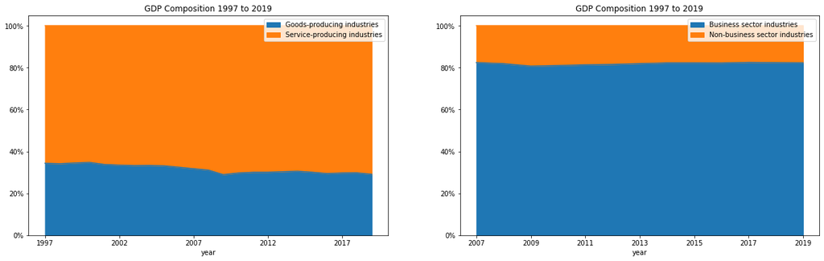

```python
fig,axs = plt.subplots(1,2,figsize=(21,6))
# divided by Goods & Services
(((gdp_annual.loc[gdp_cols[1:3],:]/gdp_annual.loc[gdp_cols[1:3],:].sum())*100).T).plot(kind='area',ax = axs[0],title='GDP Composition 1997 to 2019')
# divided by Business & Non-Business sector
(((gdp_annual.loc[gdp_cols[3:5],:]/gdp_annual.loc[gdp_cols[3:5],:].sum())*100).T.dropna()).plot(kind='area',ax = axs[1],title='GDP Composition 1997 to 2019')
axs[0].legend(loc='upper right')
axs[0].yaxis.set_major_formatter(mtick.PercentFormatter())
axs[1].legend(loc='upper right')
axs[1].yaxis.set_major_formatter(mtick.PercentFormatter())
plt.show()
```

Now let's look at a more detailed by industry gdp share view.

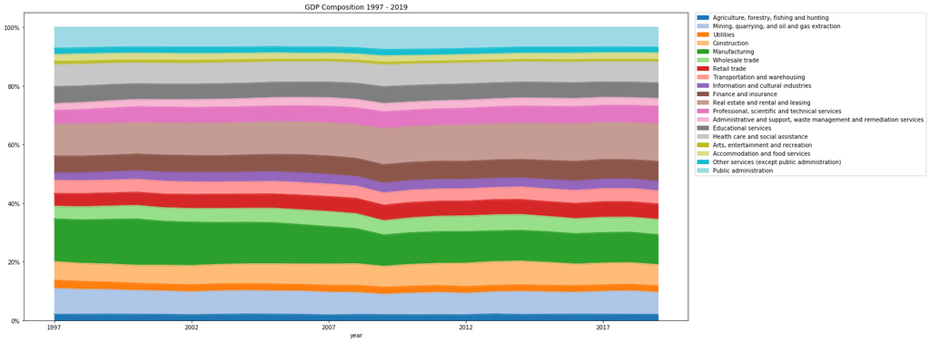

```python
# delete Management of companies and enterprises as some data point missing and the values is small
industries = gdp_cols[16:].values[gdp_cols[16:].values!='Management of companies and enterprises']
fig,ax = plt.subplots(figsize=(21,10))
# GDP shares by industries
gdp_sh_ind = (gdp_annual.loc[industries,:]/gdp_annual.loc[industries,:].sum())*100
# divided by industries
(gdp_sh_ind.T).plot(kind='area',ax = ax,title='GDP Composition 1997 - 2019',\
                                                                                 colormap='tab20')
ax.legend(bbox_to_anchor=(1.01, 1), loc='upper left', borderaxespad=0.)
ax.yaxis.set_major_formatter(mtick.PercentFormatter())
plt.show()
```

```python
# calculate change
gdp_sh_ind['2019 - 1997 change'] = gdp_sh_ind.loc[:,'2019']-gdp_sh_ind.loc[:,'1997']
(gdp_sh_ind.iloc[:,-2:].sort_values(by='2019',ascending=False)/100).style.format("{:0.2%}").background_gradient(subset='2019 - 1997 change',cmap = 'bwr')
```

| year Industry | 2019 | 2019 - 1997 change |
| --- | --- | --- |
| Real estate and rental and leasing | 12.81% | 1.80% |
| Manufacturing | 10.25% | -4.32% |
| Mining, quarrying, and oil and gas extraction | 7.52% | -1.33% |
| Construction | 7.21% | 0.87% |
| Health care and social assistance | 7.14% | -0.41% |
| Public administration | 6.80% | -0.36% |
| Finance and insurance | 6.70% | 1.02% |
| Professional, scientific and technical services | 6.03% | 1.46% |
| Educational services | 5.33% | -0.49% |
| Retail trade | 5.23% | 0.90% |
| Wholesale trade | 5.22% | 0.89% |
| Transportation and warehousing | 4.54% | 0.03% |
| Information and cultural industries | 3.27% | 0.67% |
| Administrative and support, waste management and remediation services | 2.66% | 0.36% |
| Accommodation and food services | 2.28% | -0.10% |
| Utilities | 2.23% | -0.58% |
| Agriculture, forestry, fishing and hunting | 2.06% | -0.01% |
| Other services (except public administration) | 1.94% | -0.15% |
| Arts, entertainment and recreation | 0.79% | -0.26% |

Manufacturing and mining industry is shrinking the most while real estate, tech, financial industry has gained largest shares in GDP. It seems to conform with my guess above about division of labor, moving production outside while spending more in the development of technology. The most obvious change seems to be in 2009 during the financial crisis. Manufacturing sector seem to took a big hit and never fully recovered to the origional size. However we do need more data to understand what causes these changes, such as the reasons for increasing share of real estate and financial industry. Is it because of long period of low interest and high investment need? It should be interesting to find out.

## GDP Growth Trend

Let's now turn to the growth trend to see how it looks like.

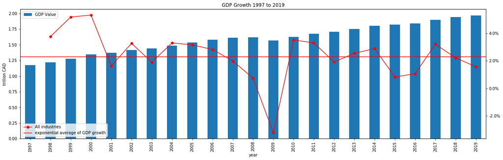

```python
# plot GDP growth chart
gdp_total = gdp_annual.loc[gdp_cols[1]]
fig,ax = plt.subplots(figsize=(21,6))
(gdp_total/1000000).plot(kind='bar',ax=ax,title="GDP Growth 1997 to 2019")
ax2 = ax.twinx()
ax2.yaxis.set_major_formatter(mtick.PercentFormatter())
(gdp_annual.loc[gdp_cols[1]].pct_change()*100).plot(ax=ax2,color='r',marker='o')
ax.set_ylabel('trillion CAD')
ax.legend(['GDP Value'])
# plot GDP growth average
ax2.axhline(((gdp_total[-1]/gdp_total[0])**(1/len(gdp_total))-1)*100,label='exponential average of GDP growth',color='r')
ax2.legend(loc='lower left')
plt.show()
```

I can see the growth rate in Canada GDP rebounded pretty strongly after the financial crisis during 2008 and 2009, then it remained relatively stable during recent years. Let's break down further to see how each industry is doing. We'll first look at the growth rate of each industry since 1997 to 2019 and also how much it contributed to the growth of the total GDP by mutiply a weight each industry takes in the whole economy.

```python
# calculate industry gdp growth
industry_growth = gdp_annual.loc[industries,:].pct_change(axis=1)
# calculate industry gdp year start weight
industry_weight = gdp_annual.loc[industries,:]/(gdp_annual.loc[industries,:].sum()).shift()
# calculate industry contribution to gdp growth
industry_contribution = industry_growth*industry_weight
```

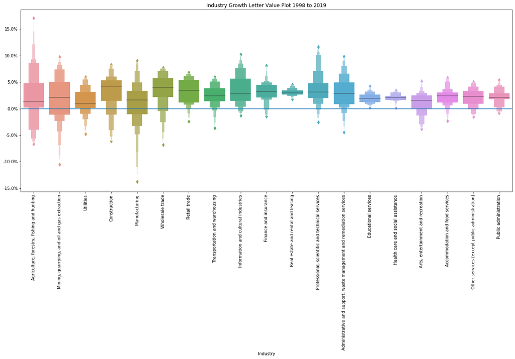

```python
# plot industry growth chart
start_year = '1998'
fig,ax = plt.subplots(figsize=(21,8))
sns.boxenplot(data = industry_growth.loc[:,start_year:].T*100,ax = ax,)
ax.set_xticklabels(industry_growth.index,rotation='vertical')
ax.yaxis.set_major_formatter(mtick.PercentFormatter())
ax.set_title(f'Industry Growth Letter Value Plot {start_year} to 2019')
ax.axhline()
plt.show()
```

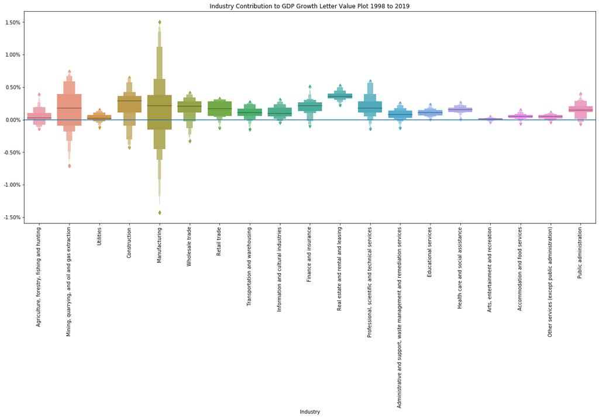

```python
# plot industry contribution to total GDP growth chart
fig,ax = plt.subplots(figsize=(21,8))
sns.boxenplot(data = industry_contribution.loc[:,start_year:].T*100,ax = ax,)
ax.set_xticklabels(industry_growth.index,rotation='vertical')
ax.yaxis.set_major_formatter(mtick.PercentFormatter())
ax.set_title(f'Industry Contribution to GDP Growth Letter Value Plot {start_year} to 2019')
ax.axhline()
plt.show()
```

Letter Value plot is basiclly a prettier version of boxplot. It gives a a very straight forward way to look at the distribution of underlying data. And the result seems really interesting. Looking at the industry growth alone, we can see industries such as IT, technology, finance, real estate all had really good years, while agriculture, mining, manufacturing tend to have huge swings in their growth. The second chart is even more interesting, we can see due to low weight in total GDP, agriculture didn't afect total GDP volatility that much. However manufacturing become the biggest influncer in GDP growth volatility. We can also see real estate remained the most steady driver in the economy those years. And the technical service industry despite the average weighting, had been a really decent GDP growth driver as well. Before we go further down let's also take a look at the correlation among different sectors.

## How Different Industries Interact

We can also learn a great deal of how economy works by looking at the interations among different industries. Let's first look at the correlation matrix.

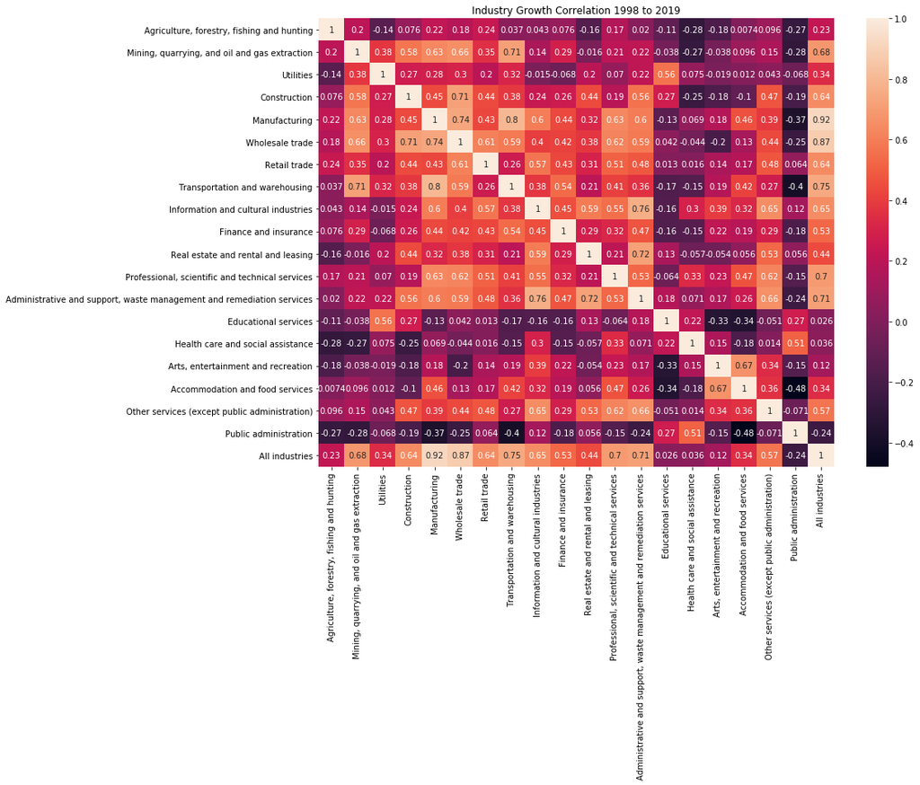

```python
fig,ax = plt.subplots(figsize=(14,10))
growth_all = industry_growth.append(gdp_annual.loc[gdp_cols[1]].pct_change())
sns.heatmap(growth_all.T.corr(), annot = True, ax = ax)
ax.set(xlabel='',ylabel='',title='Industry Growth Correlation 1998 to 2019',ylim = (len(growth_all), 0))
plt.show()
```

Another cool things we can do is to use clustering to see how the industries growth data are grouped. We'll first normalize the growth data and use Agglomerative Clustering as the clustering algorithm while using Silhouette Coefficient to determine how many clusters we should use.

```python
growth_scaled = growth_all.dropna(axis=1)
# standardardize growth dataset
growth_scaled = pd.DataFrame(scale(growth_scaled,axis=1),index = growth_scaled.index,columns=growth_scaled.columns)
# perform clustering and check Silhouette Coefficient
n_clusters = list(range(2,11))
n_scores = []
for n in n_clusters:
    clusters = AgglomerativeClustering(n_clusters = n).fit(growth_scaled)
    labels = pd.Series(clusters.labels_,growth_scaled.index)
    n_scores.append(metrics.silhouette_score(growth_scaled,labels))
```

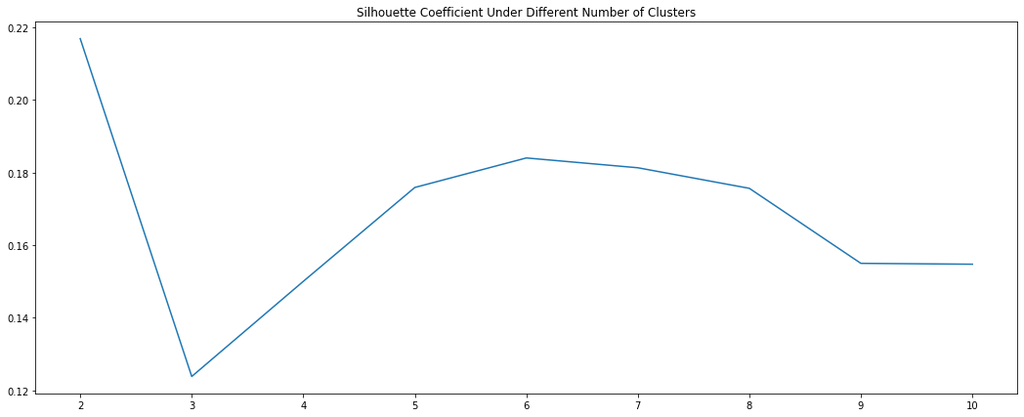

```python
pd.Series(n_scores,index=n_clusters).plot(figsize =(18,7),title='Silhouette Coefficient Under Different Number of Clusters',)
plt.show()
```

The overall Silhouette Coefficient is not very high which is not surprising, as those 20 industries classification has already gone through careful consideration by related statistical department to represent different economic segment of the country. Here we are mainly using clustering to gain a better understanding rather than prediction. Based on the chart above I believe 6 is a reasonable number of cluster we should choose.

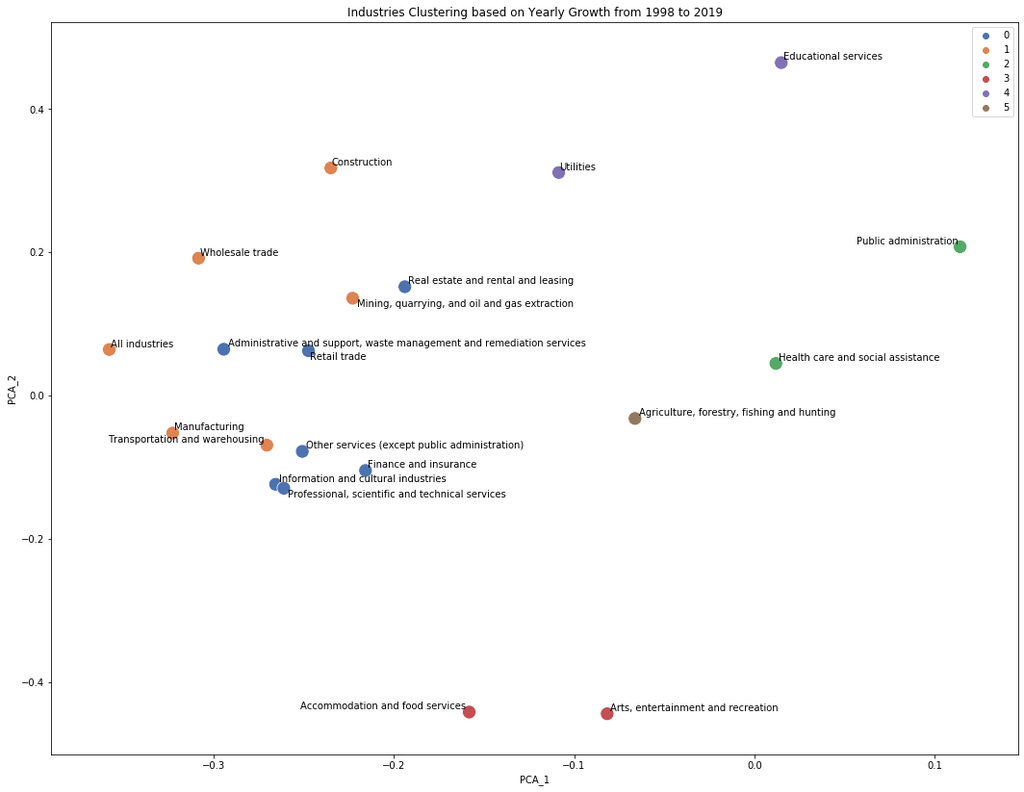

```python
# run cluster algorithm
clusters = AgglomerativeClustering(n_clusters = 6).fit(growth_scaled)
labels = pd.Series(clusters.labels_,growth_scaled.index)
# reduce 22 years of growth to 2 dimension variables with pca
pca = PCA(n_components=2).fit(growth_scaled.T)
pca_df = pd.DataFrame(pca.components_.T,index=growth_scaled.index,columns=['PCA_1','PCA_2'])

# plot
fig,ax = plt.subplots(figsize=(18,14))
sns.scatterplot(x='PCA_1',y='PCA_2',ax = ax,data=pca_df,s=200,hue=labels,palette='deep')
Labels = [ax.text(pca_df.loc[l,'PCA_1'], pca_df.loc[l,'PCA_2'], l) for l in pca_df.index]
plt.title('Industries Clustering based on Yearly Growth from 1998 to 2019')
adjust_text(Labels)
plt.show()
```

Here I reduced the 22 years of growth to 2 pca variables with 49.8% explained variance ratio and drew a scatter plot using different colors to represent different clusters. The result conforms to what we found in the correlation matrix that wholesale, construction, mining, transportation, manufacturing are all very moving along with the GDP, while accommodation,food, arts, health care, public administration, education, Agriculture are all moving in their own pace. It's interesting to see the clustering algorithm and PCA both sort of put accommodation/food and arts/entertation industries together. I guess they can both be counted as the industries provide daily necessities. It partially proves that in a developed country, as the basic living conditions are met spiritual needs becomes just as important.

## Dig Further into Key Industries

Based on what we've seen so far I belive there're certain key industries that played bigger part in driving GDP growth and worth taking a closer look such as mining, real estate, finance, manufacturing and tech industry. There're are also some industries that may not be a bigger driver in growth but takes a big share of the whole economy and are essential to the livelihood of the citizens. We'll include those as well.

```python
# get all origional col names
all_ind_cols = pd.Series(gdp_raw['North American Industry Classification System (NAICS)'].unique())
# select mining sub industry column names
minig_cols = all_ind_cols[all_ind_cols.str.contains(r'\s+\[21.{3}\]')].str.replace(r'\s+\[.+\]','').values
minig_cols = np.append(minig_cols,['Coal mining','Support activities for mining and oil and gas extraction'])
#  select real estate sub industry column names
estate_cols = all_ind_cols[all_ind_cols.str.contains(r'\s+\[53.{2,}\]')].str.replace(r'\s+\[.+\]','').values
estate_cols = np.append(estate_cols,['Lessors of non-financial intangible assets (except copyrighted works)'])
# select finance sub industry column names
finance_cols = all_ind_cols[all_ind_cols.str.contains(r'\s+\[52.{2,}\]')].str.replace(r'\s+\[.+\]','').values
finance_cols = np.delete(finance_cols,2)
finance_cols = np.append(finance_cols,['Financial investment services, funds and other financial vehicles'])
# select finance sub industry column names
manufacture_cols = all_ind_cols[all_ind_cols.str.contains(r'\s+\[3.{2}\]')].str.replace(r'\s+\[.+\]','').values
manufacture_cols  = np.delete(manufacture_cols,[3,4])
# select tech sub industry column names
tech_cols = all_ind_cols[all_ind_cols.str.contains(r'\s+\[541\d\]')].str.replace(r'\s+\[.+\]','').values
# select construction sub industry column names
construction_cols = all_ind_cols[all_ind_cols.str.contains(r'\s+\[23.{1}\]')].str.replace(r'\s+\[.+\]','').values
# select health care sub industry column names
health_care_cols = all_ind_cols[all_ind_cols.str.contains(r'\s+\[62.{1}\]')].str.replace(r'\s+\[.+\]','').values
# select public administration sub industry column names
public_admin_cols = all_ind_cols[all_ind_cols.str.contains(r'\s+\[91.{1,}\]')].str.replace(r'\s+\[.+\]','').values
public_admin_cols = np.delete(public_admin_cols,0)
# select education sub industry column names
education_cols = all_ind_cols[all_ind_cols.str.contains(r'\s+\[61.{1,}\]')].str.replace(r'\s+\[.+\]','').values
# select wholesale sub industry column names
wholesale_cols = all_ind_cols[all_ind_cols.str.contains(r'\s+\[41.{1,}\]')].str.replace(r'\s+\[.+\]','').values
# select retail sub industry column names
retail_cols = all_ind_cols[all_ind_cols.str.contains(r'\s+\[4(4|5).{1}\]')].str.replace(r'\s+\[.+\]','').values
```

```python
# set up dicitonary to loop
plot_dic = {
    'Mining, Quarrying, and Oil and Gas Extraction':minig_cols,
    'Real Estate and Rental and Leasing':estate_cols,
    'Finance and Insurance':finance_cols,
    'Manufacturing':manufacture_cols,
    'Professional, Scientific and Technical Services':tech_cols,
    'Construction':construction_cols,
    'Health Care and Social Assistance':health_care_cols,
    'Public Administration':public_admin_cols,
    'Educational Services':education_cols,
    'Wholesale Trade':wholesale_cols,
    'Retail Trade':retail_cols
}
```

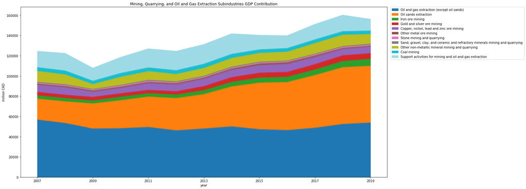

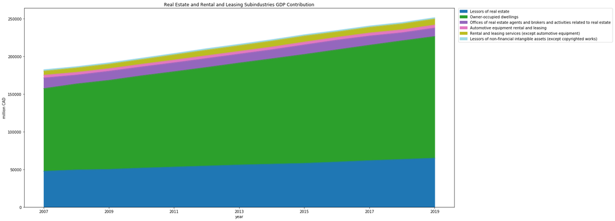

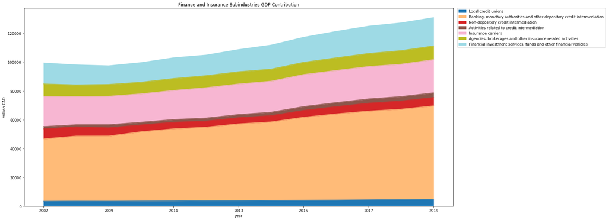

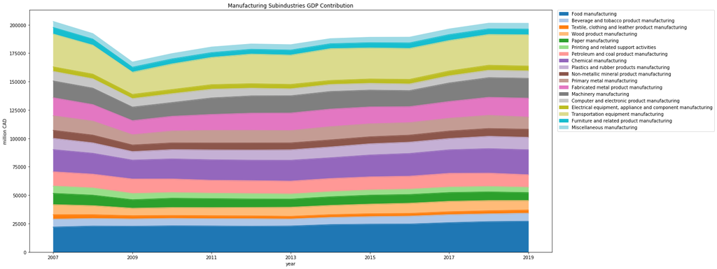

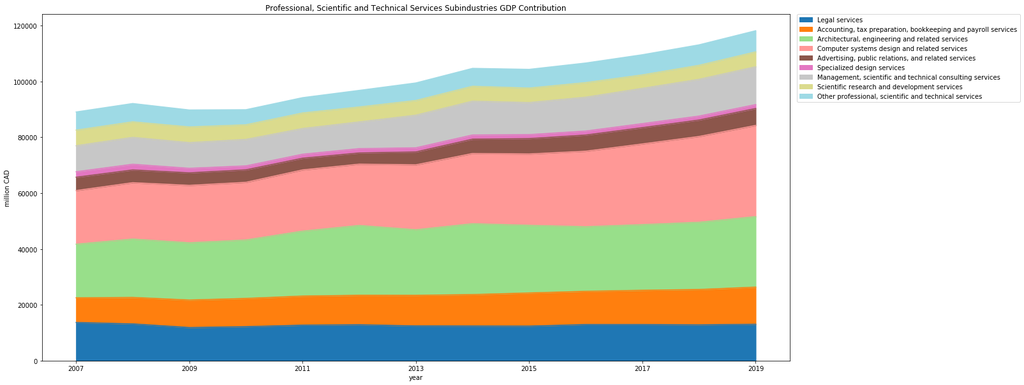

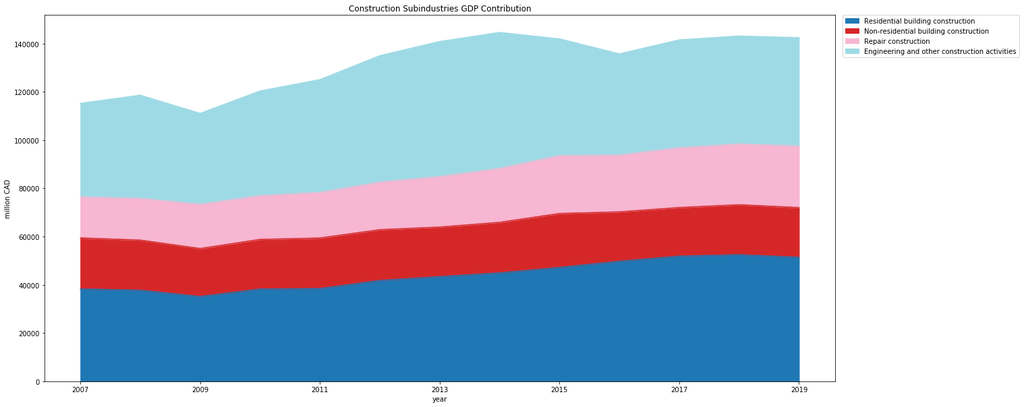

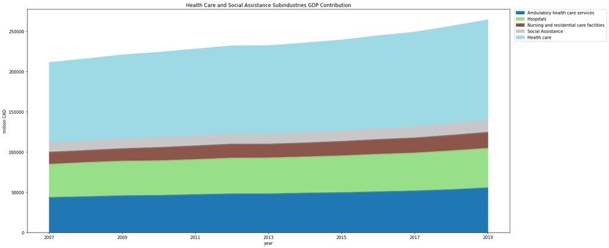

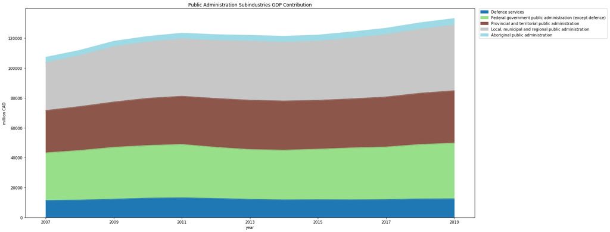

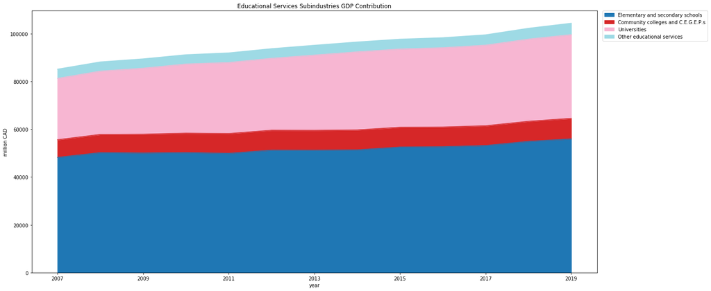

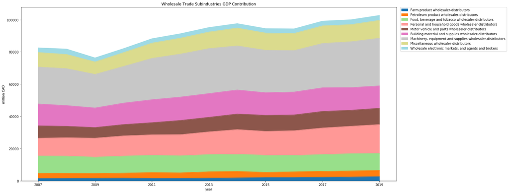

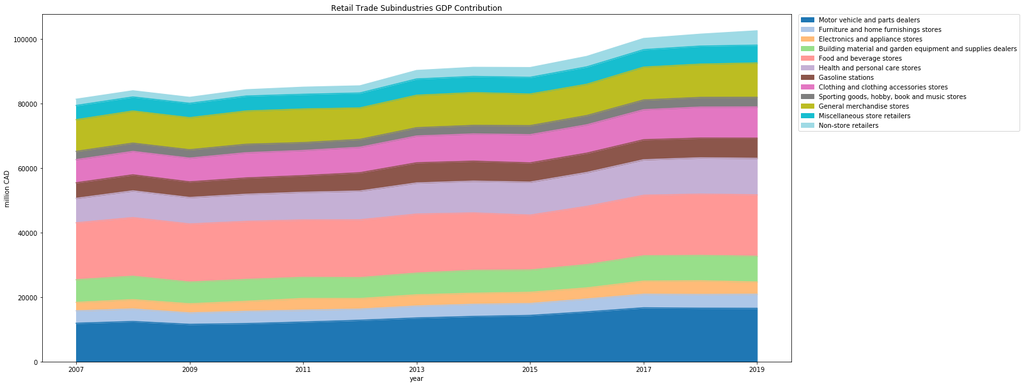

```python
for title, cols in plot_dic.items():
    ax = gdp_annual.loc[cols,'2007':].T.plot(kind='area',colormap='tab20',figsize=(21,10),title = f'{title} Subindustries GDP Contribution')
    ax.legend(bbox_to_anchor=(1.01, 1), loc='upper left', borderaxespad=0.)
    ax.set_ylabel('million CAD')
plt.show()
```

We can see some dramatic changes happening within some sectors, such as banking in finance, oil sand extraction in mining, owner-occupied dwellings in real estate etc. Even though just looking at GDP is far from understanding how the economy works in a country. I think the information above give us some really good starting point. For example we can dig further into the population data to understand what causes real estate owner to increase so steadily over the years or check on the monetary and liability data to understand further behind the expanding banking industry. I'll keep updating my findings as I go through more dataset.